# Jupyter Notebook for Advanced Astronomy

## What is Jupyter?

Advanced Astronomy notebooks combine three kinds of work in one document:

- **Markdown** for ordinary writing, headings, lists, and explanations;
- **LaTeX-style math** for scientific symbols and equations; and
- **Python** for calculations, plots, models, and reusable tools.

You are not expected to arrive already knowing any of these tools. The goal is to give you one scientific workspace in which you can explain what you are doing, carry out the calculation, and preserve a readable record of both.

## Start Jupyter on ION

1. Sign in to [ION](https://ion.tjhsst.edu/).
2. Open the applications menu (the “waffle”) and select **OnDemand**.

[figure not shown]

ION applications menu used to open OnDemand.

[figure not shown]

OnDemand page for launching a Jupyter session.

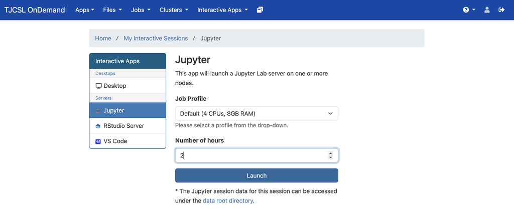

Jupyter session options before launch.

5. Wait while the session starts. The status changes when Jupyter is ready.

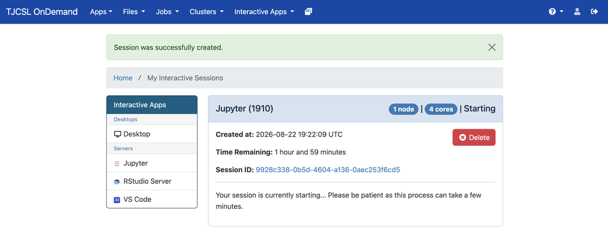

Jupyter session starting in OnDemand.

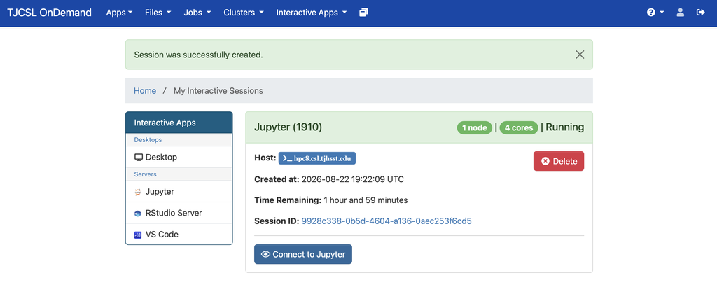

Jupyter session ready to connect.

6. Select **Connect to Jupyter**. JupyterLab will open in your browser.

[figure not shown]

JupyterLab open in a browser.

7. Select the course kernel. It should normally be called `aa_class`; an older launcher may show it as `Astronomy`. If the upper-right corner says **No Kernel** or names a different kernel, select the course kernel before running the notebook.

[figure not shown]

If you do not see the file browser, select the folder icon in the left sidebar.

**TipFirst troubleshooting check**

If imports or previously working code suddenly fail, check the kernel before changing the notebook.

## Code cells and Markdown cells

A **Code** cell runs Python. Try:

```python
print("Hello, world!")
```

Press **Shift+Enter** to run the cell and move to the next one.

A **Markdown** cell holds writing and equations. Change the cell type from **Code** to **Markdown**, then try:

```markdown
# This is a section heading

This is normal text, *italic text*, and **bold text**.

## This is a subheading

Inline math can look like $P \ne NP$.

Display math can look like this:

$$
\int_{-\infty}^{\infty} e^{-x^2}\,dx = \sqrt{\pi}
$$
```

[figure not shown]

JupyterLab control for changing a cell from Code to Markdown.

Press **Shift+Enter** to render the Markdown cell. Double-click rendered text when you want to edit its source again.

[figure not shown]

Rendered Markdown containing headings, prose, and mathematical notation.

For more detail, use the separate LaTeX guide and Python guide.

## Why this becomes useful

Python gives every notebook a calculator, plotter, and small scientific workbench. You can define constants and functions once, then reuse them instead of repeating a calculation. For example, the escape speed from a spherical body is

$$v_{\mathrm{esc}} = \sqrt{\frac{2GM}{R}}.$$

A function that accepts $M$ and $R$ can apply the same calculation to every planet while keeping the method visible and checkable. The `aa_class` kernel also includes common astronomy tools such as Astropy.

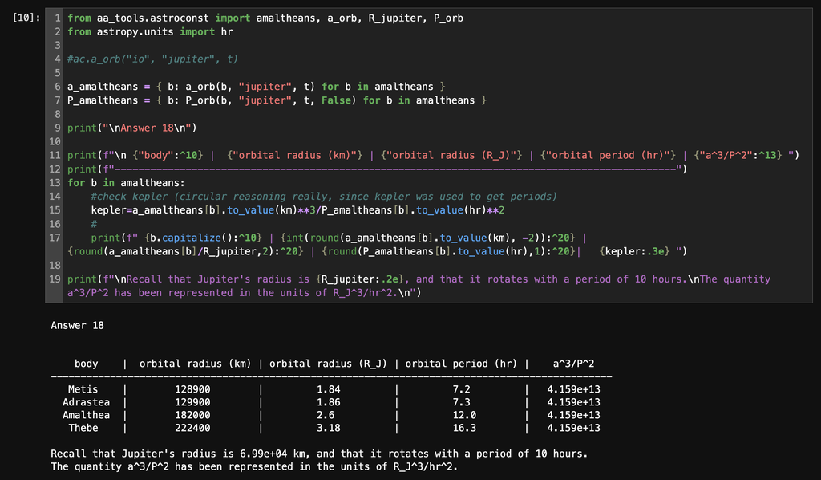

Example notebook calculation using astronomy tools.

## Open, save, and keep your work

1. Download the assigned `.ipynb` notebook from Schoology.
2. In JupyterLab, make or open a clearly named course folder.
3. Upload the notebook into that folder and open it.
4. Confirm the kernel, then run the notebook in order.
5. Save regularly. Download important work to a personal device or another approved location before your school account access ends.

If the notebook state becomes confusing, save your work, restart the kernel, and run the cells again from the beginning. Read the exact error message before rewriting code that may already be correct.